# 10 – A Notch activity score per cell

AUCell on the CollecTRI RBPJ regulon, before using it in run C

Author

Minh Le, Jeanne Leclerc

Published

October 17, 2026

## Question

In run A (notebooks 04–06), NOTCH1 on the lymphoid side was not linked to the four Notch targets we chose (HES1, DTX1, NRARP, PTCRA), and the targets followed the lymphoid population instead. Single target genes are sparse in single-cell data, and the four were picked by hand. Here we replace them with **one score per cell** computed from a published gene set, and ask whether this score behaves like a measure of Notch activity before it is used in run C (stroma → ETP + DN(early)):

1. Which genes does a database give as Notch targets, and how many are detected in our cells?
2. Is the score higher in the early T-lineage populations (Notch-dependent) than in NK cells and ILC3?
3. Does the score follow sequencing depth within each population, more than a random gene set of the same kind?
4. Within ETP and DN(early) (the receivers of run C), how does the score vary with population and donor?

**Choices and their sources.**

- *Gene set.* Notch receptors act through the DNA-binding factor RBPJ (CSL): the cleaved Notch intracellular domain binds RBPJ and turns its targets on (Kopan & Ilagan, *Cell* 2009, [doi:10.1016/j.cell.2009.03.045](https://doi.org/10.1016/j.cell.2009.03.045)). The Notch target set is the RBPJ regulon of **CollecTRI** (Müller-Dott *et al.*, *Nucleic Acids Res* 2023, [doi:10.1093/nar/gkad841](https://doi.org/10.1093/nar/gkad841)), a curated collection of signed transcription factor → target interactions with literature references (file: `data/README.md`). PROGENy (Schubert *et al.*, *Nat Commun* 2018) has no Notch pathway, so it cannot be used here.
- *Score.* **AUCell** (Aibar *et al.*, *Nat Methods* 2017, [doi:10.1038/nmeth.4463](https://doi.org/10.1038/nmeth.4463)) ranks the genes within each cell and measures how many genes of the set are near the top. It uses only ranks within a cell, so it is less tied to the total counts than a sum of counts – our main confounder in runs A and B.

## Setup

```r
library(tidyverse)
library(Matrix)
library(AUCell)

find_repo_root <- function(dir = getwd()) {
  while (!(file.exists(file.path(dir, "README.md")) && dir.exists(file.path(dir, "notebooks")))) {
    parent <- dirname(dir)
    if (parent == dir) stop("Repository root not found. Open the repository folder in Positron.")
    dir <- parent
  }
  dir
}
root <- find_repo_root()

data_dir <- file.path(root, "data", "thymus")
res_dir  <- file.path(root, "results", "thymus_early")
out_dir  <- file.path(res_dir, "10_activity_scores")
fig_dir  <- file.path(root, "results", "figures", "thymus_early")
dir.create(out_dir, recursive = TRUE, showWarnings = FALSE)
dir.create(fig_dir, recursive = TRUE, showWarnings = FALSE)

populations <- c("ETP", "DN(early)", "DN(P)", "DN(Q)", "γδT", "NK", "ILC3",   # early lymphoid
                 "cTEC", "mTEC(II)", "Fb_1", "Endo")                       # stroma
```

The cells are those exported for run A (notebook 04): all 11 populations of 7–11 PCW, at most 500 cells per population (seed 0), raw counts. ETP (127 cells) and DN(early) (201) are complete, so run C can use the same cells.

```r
input_dir <- file.path(res_dir, "04_runA_input")
counts <- readMM(file.path(input_dir, "counts.mtx.gz"))               # genes x cells
genes  <- read_csv(file.path(input_dir, "genes.csv"), show_col_types = FALSE)$gene
cells  <- read_csv(file.path(input_dir, "cells.csv"), show_col_types = FALSE) |>
  mutate(population = factor(population, levels = populations))
dimnames(counts) <- list(genes, cells$cell)
counts <- as(counts, "CsparseMatrix")
cells$n_detected <- colSums(counts > 0)

count(cells, group, population)
```

```
# A tibble: 11 × 3
   group          population     n
   <chr>          <fct>      <int>
 1 early_lymphoid ETP          127
 2 early_lymphoid DN(early)    201
 3 early_lymphoid DN(P)        500
 4 early_lymphoid DN(Q)        500
 5 early_lymphoid γδT          500
 6 early_lymphoid NK           500
 7 early_lymphoid ILC3         294
 8 stroma         cTEC         500
 9 stroma         mTEC(II)     322
10 stroma         Fb_1         500
11 stroma         Endo         233
```

## 1. The gene set

CollecTRI gives each RBPJ → target interaction a sign. AUCell ignores signs, so only targets that RBPJ **activates** are kept (`is_stimulation` true and `is_inhibition` false); repressed and ambiguous targets would lower the score of cells where Notch is active.

```r
collectri <- read_tsv(file.path(data_dir, "collectri", "collectri_human.tsv"), show_col_types = FALSE)

rbpj <- collectri |>
  filter(source_genesymbol == "RBPJ") |>
  summarise(stimulation = any(is_stimulation), inhibition = any(is_inhibition),
            curation_effort = max(curation_effort), .by = target_genesymbol) |>
  rename(gene = target_genesymbol) |>
  mutate(sign = case_when(stimulation & !inhibition ~ "activated",
                          inhibition & !stimulation ~ "repressed",
                          .default = "both"))
count(rbpj, sign)
```

```
# A tibble: 3 × 2
  sign          n
  <chr>     <int>
1 activated   105
2 both          9
3 repressed    41
```

Two more filters:

- **No ligand or receptor gene.** In run C, ligands and receptors are network variables and the L–R links are imposed. A score that contains NOTCH1 or DLL4 would be partly the same measurement as the receptor. Every gene of every partner of table S5 (complexes split into their subunits with the CellPhoneDB v2 files, as in notebook 04) is removed.
- **Present in the count matrix** (gene symbols of the atlas).

```r
db <- file.path(data_dir, "cellphonedb_v2_db", "db_2019-09")
gene_db <- read_csv(file.path(db, "gene_input.csv"), show_col_types = FALSE) |>
  distinct(uniprot, .keep_all = TRUE) |>
  mutate(gene_name = recode(gene_name, NECTIN1 = "PVRL1", NECTIN2 = "PVRL2", NECTIN3 = "PVRL3"))
complexes <- read_csv(file.path(db, "complex_input.csv"), show_col_types = FALSE) |>
  pivot_longer(uniprot_1:uniprot_4, values_to = "uniprot", values_drop_na = TRUE) |>
  left_join(gene_db, by = "uniprot") |>
  select(complex_name, gene_name)

s5 <- read_csv(file.path(res_dir, "03_ligand_receptor_candidates", "s5_oriented.csv"), show_col_types = FALSE)
partners <- unique(c(s5$ligand, s5$receptor))
lr_genes <- unique(c(setdiff(partners, complexes$complex_name),
                     complexes$gene_name[complexes$complex_name %in% partners]))
stopifnot(!anyNA(lr_genes))
length(lr_genes)
```

```
[1] 516
```

```r
rbpj <- rbpj |>
  mutate(kept = case_when(sign != "activated" ~ paste(sign, "target"),
                          gene %in% lr_genes ~ "ligand or receptor (table S5)",
                          !gene %in% genes ~ "not in the count matrix",
                          .default = "kept"))
count(rbpj, kept)
```

```
# A tibble: 4 × 2
  kept                              n
  <chr>                         <int>
1 both target                       9
2 kept                             89
3 ligand or receptor (table S5)    16
4 repressed target                 41
```

```r
filter(rbpj, kept == "ligand or receptor (table S5)")$gene
```

```
 [1] "NOTCH1"    "NOTCH3"    "CD40"      "MET"       "FLT4"      "NOTCH2"
 [7] "TNC"       "CR2"       "BMP2"      "PDCD1"     "DLL4"      "FCER2"
[13] "TNFRSF11B" "EFNB2"     "EFNB3"     "NRG1"
```

```r
notch_set <- sort(filter(rbpj, kept == "kept")$gene)
```

How often each kept gene is detected, in the run C receivers (ETP + DN(early)) and in the other groups:

```r
cell_group <- case_when(cells$population %in% c("ETP", "DN(early)") ~ "ETP + DN(early)",
                        cells$population %in% c("DN(P)", "DN(Q)") ~ "DN(P) + DN(Q)",
                        cells$population %in% c("NK", "ILC3") ~ "NK + ILC3",
                        cells$population == "γδT" ~ "γδT",
                        .default = "stroma")
detected <- map(split(seq_len(ncol(counts)), cell_group),
                \(j) rowMeans(counts[notch_set, j, drop = FALSE] > 0)) |>
  as_tibble() |>
  mutate(gene = notch_set, .before = 1) |>
  select(gene, `ETP + DN(early)`, `DN(P) + DN(Q)`, `γδT`, `NK + ILC3`, stroma) |>
  arrange(desc(`ETP + DN(early)`))

c(genes_in_set = length(notch_set),
  detected_in_5pct_of_ETP_DNearly = sum(detected$`ETP + DN(early)` >= 0.05),
  never_detected_in_these_cells = sum(rowSums(counts[notch_set, ] > 0) == 0))
```

```
                   genes_in_set detected_in_5pct_of_ETP_DNearly
                             89                              50
  never_detected_in_these_cells
                              5
```

```r
detected |> head(25) |> mutate(across(where(is.numeric), \(x) round(x, 2)))
```

```
# A tibble: 25 × 6
   gene   `ETP + DN(early)` `DN(P) + DN(Q)`   γδT `NK + ILC3` stroma
   <chr>              <dbl>           <dbl> <dbl>       <dbl>  <dbl>
 1 CDK6                0.8             0.78  0.6         0.24   0.28
 2 DUSP1               0.73            0.8   0.83        0.8    0.64
 3 GAMT                0.67            0.49  0.6         0.26   0.54
 4 MT2A                0.63            0.35  0.29        0.34   0.18
 5 MDFIC               0.62            0.41  0.44        0.39   0.15
 6 REL                 0.62            0.39  0.56        0.62   0.54
 7 CASP3               0.55            0.28  0.4         0.39   0.2
 8 CCND3               0.53            0.58  0.67        0.4    0.26
 9 GATA3               0.5             0.52  0.62        0.34   0.09
10 FCER1G              0.48            0.14  0.2         0.74   0.04
# ℹ 15 more rows
```

## 2. Scoring

AUCell ranks the genes of each cell; genes with the same value (most of them at 0) are put in random order, hence the seed. The score looks only at the top `aucMaxRank` genes of each ranking. The AUCell vignette asks that most cells detect at least that many genes; otherwise the end of the window falls among random zeros. The default (5% of 33,694 genes = 1,685) is above the number of genes detected by 16% of the cells, so the window is set to the **10th percentile of detected genes**: 90% of the cells have at least that many.

```r
quantile(cells$n_detected, c(0.05, 0.1, 0.25, 0.5))
```

```
    5%    10%    25%    50%
1228.0 1450.2 2001.0 2767.0
```

```r
max_rank <- floor(quantile(cells$n_detected, 0.1))
max_rank
```

```
 10%
1450
```

```r
set.seed(0)
rankings <- AUCell_buildRankings(counts, plotStats = FALSE, splitByBlocks = TRUE, verbose = FALSE)
notch_auc <- getAUC(AUCell_calcAUC(list(notch = notch_set), rankings, aucMaxRank = max_rank, verbose = FALSE))
cells$notch_auc <- notch_auc["notch", cells$cell]
```

**Control gene sets.** A score can differ between populations simply because some populations detect more genes (median 1727.5 to 4466 here). To see what is specific to the Notch set, the same score is computed for 100 random gene sets of the same size, in which each Notch gene is replaced by a random gene detected in a similar fraction of cells (same twentieth of the detection distribution). The **adjusted score** is the Notch score minus the mean score of the random sets in the same cell.

```r
detection <- rowMeans(counts > 0)
pool <- names(detection)[detection > 0 & !names(detection) %in% c(notch_set, lr_genes)]
bins <- cut(detection, breaks = unique(quantile(detection[pool], seq(0, 1, 0.05))), include.lowest = TRUE)
names(bins) <- names(detection)

set.seed(1)
control_sets <- map(1:100, \(i) map_chr(notch_set, \(g) {
  same_bin <- pool[bins[pool] == bins[g]]
  if (length(same_bin) == 0 || is.na(bins[g])) same_bin <- pool    # genes never detected: any gene
  sample(same_bin, 1)
}))
names(control_sets) <- paste0("control_", 1:100)
control_matrix <- getAUC(AUCell_calcAUC(control_sets, rankings, aucMaxRank = max_rank, verbose = FALSE))

cells$control_auc <- colMeans(control_matrix[, cells$cell])
cells$notch_adjusted <- cells$notch_auc - cells$control_auc
```

## 3. Is the score higher where Notch is expected to be active?

Notch signalling specifies the T lineage in thymic progenitors and is needed up to β-selection; in human thymus it is active in CD34⁺ progenitors and developing thymocytes (García-León *et al.*, *Development* 2018, [doi:10.1242/dev.165597](https://doi.org/10.1242/dev.165597)), and strong Notch signals also favour γδ T cells (Van de Walle *et al.*, *J Exp Med* 2013, [doi:10.1084/jem.20121798](https://doi.org/10.1084/jem.20121798)). Expected: ETP, DN(early), DN(P), DN(Q) and γδT above NK and ILC3. The stroma is not a negative control: endothelial cells use Notch signalling themselves.

```r
by_population <- cells |>
  summarise(cells = n(), notch_auc = median(notch_auc), control_auc = median(control_auc),
            notch_adjusted = median(notch_adjusted), .by = population) |>
  arrange(population)
by_population |> mutate(across(c(notch_auc, control_auc, notch_adjusted), \(x) signif(x, 2)))
```

```
# A tibble: 11 × 5
   population cells notch_auc control_auc notch_adjusted
   <fct>      <int>     <dbl>       <dbl>          <dbl>
 1 ETP          127     0.035       0.026         0.0095
 2 DN(early)    201     0.033       0.02          0.012
 3 DN(P)        500     0.047       0.022         0.025
 4 DN(Q)        500     0.056       0.027         0.029
 5 γδT          500     0.04        0.023         0.017
 6 NK           500     0.041       0.028         0.013
 7 ILC3         294     0.048       0.027         0.021
 8 cTEC         500     0.039       0.026         0.013
 9 mTEC(II)     322     0.037       0.025         0.011
10 Fb_1         500     0.018       0.027        -0.0085
11 Endo         233     0.035       0.026         0.0093
```

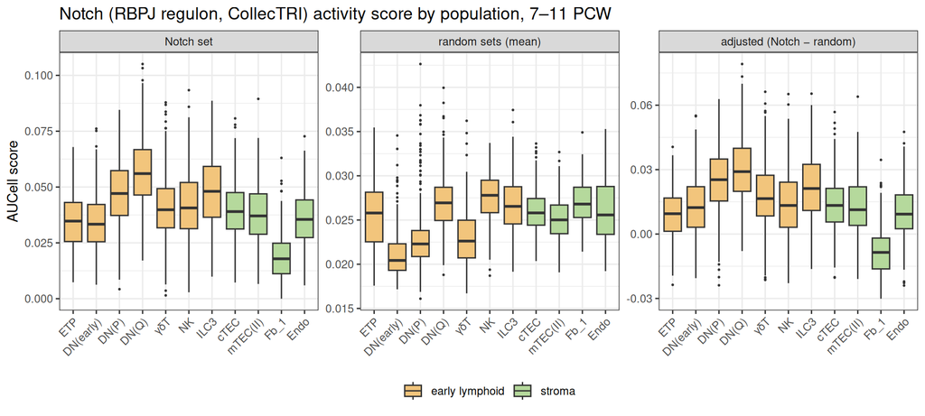

Figure 1

```r
plot_data <- cells |>
  select(population, group, `Notch set` = notch_auc, `random sets (mean)` = control_auc,
         `adjusted (Notch − random)` = notch_adjusted) |>
  pivot_longer(-c(population, group), names_to = "score") |>
  mutate(score = fct_inorder(score))
p <- ggplot(plot_data, aes(population, value, fill = group)) +
  geom_boxplot(outlier.size = 0.3) +
  facet_wrap(~score, scales = "free_y") +
  scale_fill_manual(values = c(stroma = "#b5d99c", early_lymphoid = "#f2c57c"),
                    labels = c(stroma = "stroma", early_lymphoid = "early lymphoid")) +
  labs(x = NULL, y = "AUCell score", fill = NULL,
       title = "Notch (RBPJ regulon, CollecTRI) activity score by population, 7–11 PCW") +
  theme_bw() +
  theme(axis.text.x = element_text(angle = 45, hjust = 1), legend.position = "bottom")
p
ggsave(file.path(fig_dir, "10_notch_score_by_population.png"), p, width = 10, height = 4.5, dpi = 150)
```

## 4. Does the score follow sequencing depth?

Within each population, Spearman correlation of each score with the total counts of the cell (`n_counts`). For the random sets, the median correlation over the 100 sets.

```r
depth <- cells |>
  summarise(cells = n(),
            notch = cor(notch_auc, n_counts, method = "spearman"),
            random_sets_median = median(apply(control_matrix[, cell, drop = FALSE], 1,
                                              \(a) cor(a, n_counts, method = "spearman"))),
            adjusted = cor(notch_adjusted, n_counts, method = "spearman"),
            .by = population) |>
  arrange(population)
depth |> mutate(across(where(is.double), \(x) round(x, 2)))
```

```
# A tibble: 11 × 5
   population cells notch random_sets_median adjusted
   <fct>      <int> <dbl>              <dbl>    <dbl>
 1 ETP          127 -0.13              -0.29     0.1
 2 DN(early)    201  0.1               -0.23     0.27
 3 DN(P)        500  0.16              -0.23     0.3
 4 DN(Q)        500  0.11              -0.18     0.25
 5 γδT          500  0.19              -0.24     0.35
 6 NK           500  0.1               -0.17     0.23
 7 ILC3         294 -0.11              -0.22     0.05
 8 cTEC         500  0.29              -0.16     0.4
 9 mTEC(II)     322  0.17              -0.19     0.31
10 Fb_1         500  0.05              -0.16     0.22
11 Endo         233  0                 -0.27     0.22
```

## 5. Within the run C receivers

```r
receivers <- filter(cells, population %in% c("ETP", "DN(early)")) |> droplevels()
receivers |>
  summarise(cells = n(), notch_auc = median(notch_auc), notch_adjusted = median(notch_adjusted),
            .by = c(population, donor)) |>
  arrange(population, desc(cells)) |>
  mutate(across(c(notch_auc, notch_adjusted), \(x) signif(x, 2)))
```

```
# A tibble: 12 × 5
   population donor cells notch_auc notch_adjusted
   <fct>      <chr> <int>     <dbl>          <dbl>
 1 ETP        C40      99     0.035         0.0095
 2 ETP        F23      11     0.027         0.0065
 3 ETP        C41      11     0.042         0.022
 4 ETP        F74       4     0.022        -0.0006
 5 ETP        F22       2     0.041         0.016
 6 DN(early)  C40      86     0.037         0.016
 7 DN(early)  F23      31     0.03          0.0079
 8 DN(early)  F64      31     0.027         0.0055
 9 DN(early)  C41      23     0.044         0.023
10 DN(early)  F74      19     0.035         0.016
11 DN(early)  C34       9     0.025         0.0015
12 DN(early)  F22       2     0.032        -0.0015
```

```r
wilcox.test(notch_adjusted ~ population, data = receivers)$p.value
```

```
[1] 0.01720394
```

```r
kruskal.test(notch_adjusted ~ donor, data = filter(receivers, population == "DN(early)"))$p.value
```

```
[1] 1.541309e-08
```

## 6. Export

```r
rbpj |>
  select(gene, sign, curation_effort, kept) |>
  arrange(kept != "kept", gene) |>
  write_csv(file.path(out_dir, "notch_gene_set.csv"))
cells |>
  select(cell, population, donor, n_counts, n_detected, notch_auc, control_auc, notch_adjusted) |>
  write_csv(file.path(out_dir, "notch_scores.csv"))
writeLines(c(paste("aucMaxRank:", max_rank), paste("genes in the Notch set:", length(notch_set))),
           file.path(out_dir, "settings.txt"))
list.files(out_dir)
```

```
[1] "notch_gene_set.csv" "notch_scores.csv"   "settings.txt"
```

## Summary

[output not shown]

**Why the score fails.** The CollecTRI regulon collects RBPJ targets reported in any tissue. The 89 genes include pancreatic (PDX1, PTF1A), neural (SOX2, NEUROG1), erythroid (HBB, AHSP) and T-helper (IL17A, FOXP3, TBX21) genes, and broadly expressed genes (DUSP1, MT2A, CDK6, REL, NFKB1, NFKB2). The genes most often detected in our cells are of the last kind. The known T-lineage Notch targets are only 6 of the 89 (HES1, DTX1, NRARP, PTCRA, GATA3, TCF7). Taken one at a time, they do follow the expected pattern (for example DTX1 is detected in 34% of ETP + DN(early) cells and 3% of NK + ILC3), but the rest of the set hides them.

**Consequence.** This score is not used in run C. A Notch score for thymocytes would need a gene set measured in human T-lineage cells (for example genes that respond to Notch ligands in human CD34⁺ progenitors), which no database used here provides.